# 1 Introduction

### 4.8 Remove Padding (9)

```python
def build_model_9():
    inputs = keras.Input(shape=(32, 32, 3))
    x = layers.Rescaling(1./255)(inputs)

    x = layers.Conv2D(filters=256, kernel_size=3, activation="relu")(x)
    x = layers.MaxPooling2D(2)(x)

    x = layers.Conv2D(filters=512, kernel_size=3, activation="relu")(x)
    x = layers.MaxPooling2D(2)(x)

    x = layers.Conv2D(filters=1024, kernel_size=3, activation="relu")(x)

    x = layers.Flatten()(x)
    x = layers.Dense(512, activation='relu')(x)
    outputs = layers.Dense(100, activation="softmax")(x)

    model = keras.Model(inputs=inputs, outputs=outputs)
    return model

model_9 = build_model_9()
```

```python
model_9.compile(
    optimizer=keras.optimizers.Adam(1e-4),
    loss = 'categorical_crossentropy',
    metrics=['accuracy'],
)

history_9 = model_9.fit(
    train_images,
    train_labels,
    epochs=20,
    verbose=2,
    validation_split=0.2
)
```

```python
get_max_acc_min_loss_epoch(history_9, 'Model 9: No Padding')
```

```
Model 9: No Padding
Max Validation Accuracy:  40.14 %	 Num Epoch:  10
Min Validation Loss:  2.51796 		 Num Epoch:  7
```

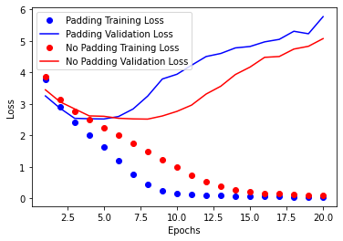

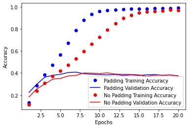

```
(None, None)
```

```python
compare_loss_acc(history_8e, history_9, 'Padding','No Padding')
```

### 4.9 4 Conv2D Layers with 8 Base (10)

Test the addition of another block of Conv2D and Maxpooling layers. Padding must be used however or else final filters get reduced too negative values.

```python
def build_model_10():
    inputs = keras.Input(shape=(32, 32, 3))
    x = layers.Rescaling(1./255)(inputs)

    x = layers.Conv2D(filters=128, kernel_size=3, activation="relu", padding='same')(x)
    x = layers.MaxPooling2D(2)(x)

    x = layers.Conv2D(filters=256, kernel_size=3, activation="relu", padding='same')(x)
    x = layers.MaxPooling2D(2)(x)

    x = layers.Conv2D(filters=512, kernel_size=3, activation="relu", padding='same')(x)
    x = layers.MaxPooling2D(2)(x)

    x = layers.Conv2D(filters=1024, kernel_size=3, activation="relu", padding='same')(x)

    x = layers.Flatten()(x)
    x = layers.Dense(512, activation='relu')(x)
    outputs = layers.Dense(100, activation="softmax")(x)

    model = keras.Model(inputs=inputs, outputs=outputs, name='Model_10_4_Conv2d_layers')
    return model

model_10 = build_model_10()
```

```python
model_10.compile(
    optimizer=keras.optimizers.Adam(1e-4),
    loss = 'categorical_crossentropy',
    metrics=['accuracy'],
)

history_10 = model_10.fit(
    train_images,
    train_labels,
    epochs=25,
    verbose=2,
    validation_split=0.2
)
```

```
Model 10: 4 Conv2D
Max Validation Accuracy:  39.76 %	 Num Epoch:  6
Min Validation Loss:  2.4469 		 Num Epoch:  5
Model 9: 3 Conv2D
Max Validation Accuracy:  40.14 %	 Num Epoch:  10
Min Validation Loss:  2.51796 		 Num Epoch:  7
```

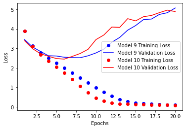

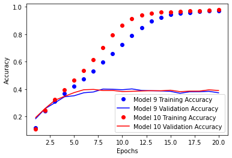

```
(None, None)
```

```python
get_max_acc_min_loss_epoch(history_10, 'Model 10: 4 Conv2D')
get_max_acc_min_loss_epoch(history_9, 'Model 9: 3 Conv2D')
compare_loss_acc(history_9, history_10, 'Model 9','Model 10')
```

Additional layer reduced loss and model trained fairly quickly to reach overfitting.

### 4.10 Data Augmentation (Aug)

The use of data augmentation can have the effect of reducing overfitting by creating more noise in the training data and making the model more resiliant to new data. Images are altered using transformations such as zooming, rotating, translation and others. It has the effect of exposing the network to new variants of the data that would otherwise would not be visible.

```python
data_augmentation = keras.Sequential([
      layers.RandomFlip('horizontal_and_vertical', input_shape=(32,32,3)),
      layers.RandomRotation(0.2),
      layers.RandomZoom(0.2)
])

def build_model_augment_1():
    inputs = keras.Input(shape=(32, 32, 3))
    x = data_augmentation(inputs)
    x = layers.Rescaling(1./255)(x)

    x = layers.Conv2D(filters=128, kernel_size=3, activation="relu", padding='same')(x)
    x = layers.MaxPooling2D(2)(x)

    x = layers.Conv2D(filters=256, kernel_size=3, activation="relu", padding='same')(x)
    x = layers.MaxPooling2D(2)(x)

    x = layers.Conv2D(filters=512, kernel_size=3, activation="relu", padding='same')(x)
    x = layers.MaxPooling2D(2)(x)

    x = layers.Conv2D(filters=1024, kernel_size=3, activation="relu", padding='same')(x)

    x = layers.Flatten()(x)
    x = layers.Dense(512, activation='relu')(x)
    outputs = layers.Dense(100, activation="softmax")(x)

    model = keras.Model(inputs=inputs, outputs=outputs, name='model_augment_1')
    return model

model_augment_1 = build_model_augment_1()
```

```python
model_augment_1.compile(
    optimizer=keras.optimizers.Adam(1e-4),
    loss = 'categorical_crossentropy',
    metrics=['accuracy'],
)

history_augment_1 = model_augment_1.fit(
    train_images,
    train_labels,
    epochs=30,
    verbose=2,
    validation_split=0.2
)
```

[output not shown]

```
1250/1250 - 262s - loss: 4.0799 - accuracy: 0.0755 - val_loss: 4.3276 - val_accuracy: 0.0753 - 262s/epoch - 210ms/step
```

[output not shown]

[output cut: 18 more lines]

[output not shown]

```
Model: Augmentation
Max Validation Accuracy:  38.67 %	 Num Epoch:  16
Min Validation Loss:  2.58126 		 Num Epoch:  13
Model: No Augmentation
Max Validation Accuracy:  38.03 %	 Num Epoch:  18
Min Validation Loss:  2.57872 		 Num Epoch:  18
```

[figure not shown]

```python
get_max_acc_min_loss_epoch(history_augment_1, 'Model: Augmentation')
get_max_acc_min_loss_epoch(history_10, 'Model: No Augmentation')
plot_val_loss_acc(history_augment_1)
```

[figure not shown]

[figure not shown]

```python
compare_acc(history_8, history_augment_1, '8: No Augmentation',' Augmentation')
compare_loss(history_8, history_augment_1, '8: No Augmentation',' Augmentation')
```

### 4.11 Increase Dense Layers w. Dropout (11)

This will test a variety of dense layer units and dropout rates after the current convolutional network. Currently the model is overfitting rather quickly. Dropout layers should help to reduce the overfitting and make the model more resiliant to new data in validation.

Try increasing the model size again with an additional dense and dropout layer. Unable to include data augmentation preprocessing going forward due to bug with Keras (https://github.com/keras-team/keras-cv/issues/291).

```python
def build_model_11(dropout=0.5, num_layers=1, units=512):
    inputs = keras.Input(shape=(32, 32, 3))

    x = layers.Rescaling(1./255)(inputs)


    x = layers.Conv2D(filters=128, kernel_size=3, activation="relu", padding='same')(x)
    x = layers.MaxPooling2D(2)(x)

    x = layers.Conv2D(filters=256, kernel_size=3, activation="relu", padding='same')(x)
    x = layers.MaxPooling2D(2)(x)

    x = layers.Conv2D(filters=512, kernel_size=3, activation="relu", padding='same')(x)
    x = layers.MaxPooling2D(2)(x)

    x = layers.Conv2D(filters=1024, kernel_size=3, activation="relu", padding='same')(x)

    x = layers.Flatten()(x)
    for i in list(range(1, num_layers+1)):
      x = layers.Dense(units, activation='relu')(x)
      x = layers.Dropout(dropout)(x)

    outputs = layers.Dense(100, activation="softmax")(x)

    model = keras.Model(inputs=inputs, outputs=outputs, name='Model_Augmentation_W_Dropout')
    return model

model_11a = build_model_11(0.5, 1)
model_11b = build_model_11(0.5, 2)
model_11c = build_model_11(0.3, 1)
model_11d = build_model_11(0.3, 2)
model_11e = build_model_11(0.5, 2, 256)
model_11f = build_model_11(0.2, 1, 1024)
model_11g = build_model_11(0.5, 3, 512)
model_11s = [
    model_11a,
    model_11b,
    model_11c,
    model_11d,
    model_11e,
    model_11f,
]
```

```python
model_11_results = []
for model in model_11s:
    model.compile(
      optimizer=keras.optimizers.Adam(1e-4),
      loss = 'categorical_crossentropy',
      metrics=['accuracy'],
    )

    history = model.fit(
        train_images,
        train_labels,
        epochs=25,
        verbose=2,
        validation_split=0.2
    )
    model_11_results.append(history)
```

```python
for i, hist in enumerate(model_11_results):
  get_max_acc_min_loss_epoch(hist, f'Model 11.{i}')
```

```
Model 11.0
Max Validation Accuracy:  45.23 %	 Num Epoch:  15
Min Validation Loss:  2.23111 		 Num Epoch:  9
Model 11.1
Max Validation Accuracy:  48.29 %	 Num Epoch:  16
Min Validation Loss:  2.08228 		 Num Epoch:  13
Model 11.2
Max Validation Accuracy:  42.94 %	 Num Epoch:  24
Min Validation Loss:  2.30694 		 Num Epoch:  7
Model 11.3
Max Validation Accuracy:  46.129999999999995 %	 Num Epoch:  16
Min Validation Loss:  2.19655 		 Num Epoch:  10
Model 11.4
Max Validation Accuracy:  46.98 %	 Num Epoch:  24
Min Validation Loss:  2.14611 		 Num Epoch:  18
Model 11.5
Max Validation Accuracy:  41.88 %	 Num Epoch:  12
Min Validation Loss:  2.36719 		 Num Epoch:  4
```

```python
get_max_acc_min_loss_epoch(history_11g, 'Model 11g')
```

```
Model 11g
Max Validation Accuracy:  43.84 %	 Num Epoch:  18
Min Validation Loss:  2.34902 		 Num Epoch:  13
```

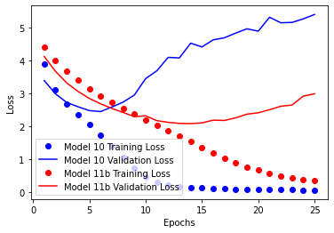

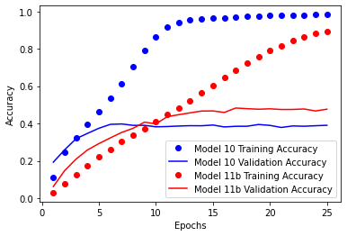

```
(None, None)
```

```python
compare_loss_acc(history_10, model_11_results[1], 'Model 10', 'Model 11b')
```

Adding dropout layers and more dense layers resulted in a large improvement. Two blocks of a 512 unit dense layers and dropout layer with a rate of 0.5 resulted in a validation accuarcy of 48.29% and validation loss of 2.082. Model 11g will test whether a 3rd block of dense and dropout layers continues to improve the model but validation loss incrceased by quite a bit in this configuration.

```python
model_11g.compile(
  optimizer=keras.optimizers.Adam(1e-4),
  loss = 'categorical_crossentropy',
  metrics=['accuracy'],
)

history_11g = model_11g.fit(
    train_images,
    train_labels,
    epochs=25,
    verbose=2,
    validation_split=0.2
)
```

### 4.12 Batch Normalization (12)

Test the use of batch normalization layers to reduce overfitting. This is acomplished by normalizing the data outputted by intermediate layers in the network.

```python
def build_model_12():
    inputs = keras.Input(shape=(32, 32, 3))

    x = layers.Rescaling(1./255)(inputs)

    x = layers.Conv2D(filters=128, kernel_size=3, use_bias=False, padding='same')(x)
    x = layers.BatchNormalization()(x)
    x = layers.Activation('relu')(x)
    x = layers.MaxPooling2D(2)(x)

    x = layers.Conv2D(filters=256, kernel_size=3, use_bias=False, padding='same')(x)
    x = layers.BatchNormalization()(x)
    x = layers.Activation('relu')(x)
    x = layers.MaxPooling2D(2)(x)

    x = layers.Conv2D(filters=512, kernel_size=3, use_bias=False, padding='same')(x)
    x = layers.BatchNormalization()(x)
    x = layers.Activation('relu')(x)

    x = layers.Conv2D(filters=1024, kernel_size=3, use_bias=False, activation='relu', padding='same')(x)


    x = layers.Flatten()(x)

    x = layers.Dense(512, activation='relu')(x)
    x = layers.Dropout(0.5)(x)

    x = layers.Dense(512, activation='relu')(x)
    x = layers.Dropout(0.5)(x)


    outputs = layers.Dense(100, activation="softmax")(x)

    model = keras.Model(inputs=inputs, outputs=outputs, name='Model_13_Batch_Normalization')
    return model

model_12 = build_model_12()
```

```python
model_12.compile(
    optimizer=keras.optimizers.Adam(1e-4),
    loss = 'categorical_crossentropy',
    metrics=['accuracy'],
)

history_12 = model_12.fit(
    train_images,
    train_labels,
    epochs=30,
    verbose=2,
    validation_split=0.2
)
```

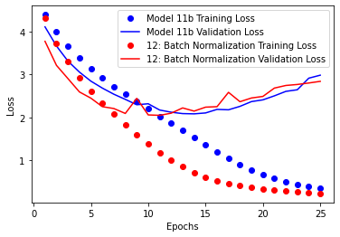

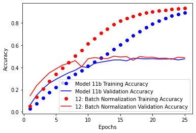

```
Model 12: Batch Normalization
Max Validation Accuracy:  50.080000000000005 %	 Num Epoch:  13
Min Validation Loss:  2.04718 		 Num Epoch:  10
```

```python
compare_loss_acc(model_11_results[1], history_12, 'Model 11b', '12: Batch Normalization')
get_max_acc_min_loss_epoch(history_12, 'Model 12: Batch Normalization')
```

The use of batch normalization did further increase validation accuracy and reduce loss. Overfitting began at 10 epochs.

### 4.13 Residuals (13)

The use of residual connections aims to reduce the propogation of noise through successive layers by adding the input of a layer or block of layers back to its output.

```python
def build_model_14():
    inputs = keras.Input(shape=(32, 32, 3))

    x = layers.Rescaling(1./255)(inputs)

    def residual_block(x, filters, pooling=False):
      residual = x
      x = layers.BatchNormalization()(x)
      x = layers.Conv2D(filters, 3, activation="relu", padding="same")(x)
      x = layers.Conv2D(filters, 3, activation="relu", padding="same")(x)
      if pooling:
        x = layers.MaxPooling2D(2, padding="same")(x)
        residual = layers.Conv2D(filters, 1, strides=2)(residual)
      elif filters != residual.shape[-1]:
        residual = layers.Conv2D(filters, 1)(residual)
      x = layers.add([x, residual])
      return x

    x = residual_block(x, 128, pooling=True)
    x = residual_block(x, 256, pooling=True)
    x = residual_block(x, 512, pooling=True)

    x = layers.Conv2D(filters=1024, kernel_size=3, use_bias=False, activation='relu', padding='same')(x)

    x = layers.Flatten()(x)

    x = layers.Dense(512, activation='relu')(x)
    x = layers.Dropout(0.5)(x)

    x = layers.Dense(512, activation='relu')(x)
    x = layers.Dropout(0.5)(x)

    outputs = layers.Dense(100, activation="softmax")(x)

    model = keras.Model(inputs=inputs, outputs=outputs, name='Model_14_Residuals')
    return model

model_14 = build_model_14()
```

```python
model_14.compile(
    optimizer=keras.optimizers.Adam(1e-4),
    loss = 'categorical_crossentropy',
    metrics=['accuracy'],
)

history_14 = model_14.fit(
    train_images,
    train_labels,
    epochs=40,
    verbose=2,
    validation_split=0.2
)
```

```python
get_max_acc_min_loss_epoch(history_14, 'Model 13: Residuals')
```

```
Model 13: Residuals
Max Validation Accuracy:  51.83 %	 Num Epoch:  10
Min Validation Loss:  1.94449 		 Num Epoch:  7
```

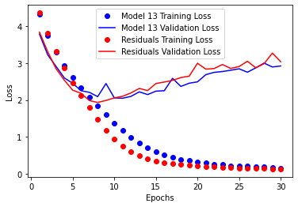

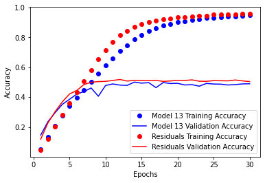

```
(None, None)
```

```python
compare_loss_acc(history_12, history_14, 'Model 13', 'Residuals')
```

The addition of resudiuals made a significant improvement to the model. The use of residuals helps to reduce the noise that gets propogated through a network through successive layers. As the model begins to grow with more layers, the more the noise of each layer can affect the final output. Adding the residuals back into the model helps to keep the base information in tact and successively adds to the predictive accuracy of this network. This model achieved an accuarcy of 51.8% and began overfitting at 7 epochs.

### 4.14 Depthwise Separable Convolution Layers (14)

```python
def build_model_15():
    inputs = keras.Input(shape=(32, 32, 3))

    x = layers.Rescaling(1./255)(inputs)
    # need a conv2d layer to begin to handle color
    x = layers.Conv2D(128, 3, activation='relu', padding='same')(x)

    def residual_block(x, filters, pooling=False):
      residual = x
      x = layers.BatchNormalization()(x)
      x = layers.Activation("relu")(x)
      x = layers.SeparableConv2D(filters, 3, padding="same", use_bias=False)(x)

      x = layers.BatchNormalization()(x)
      x = layers.Activation("relu")(x)
      x = layers.SeparableConv2D(filters, 3, padding="same", use_bias=False)(x)

      if pooling:
        x = layers.MaxPooling2D(2, padding="same")(x)
        residual = layers.Conv2D(filters, 1, strides=2)(residual)
      elif filters != residual.shape[-1]:
        residual = layers.Conv2D(filters, 1)(residual)
      x = layers.add([x, residual])
      return x

    x = residual_block(x, 128, pooling=True)
    x = residual_block(x, 256, pooling=True)
    x = residual_block(x, 512, pooling=True)

    x = layers.Conv2D(filters=1024, kernel_size=3, use_bias=False, activation='relu', padding='same')(x)

    x = layers.Flatten()(x)

    x = layers.Dense(512, activation='relu')(x)
    x = layers.Dropout(0.5)(x)

    x = layers.Dense(512, activation='relu')(x)
    x = layers.Dropout(0.5)(x)


    outputs = layers.Dense(100, activation="softmax")(x)

    model = keras.Model(inputs=inputs, outputs=outputs, name='Model_16_Residuals')

    return model


model_15 = build_model_15()
```

```python
model_15.compile(
    optimizer=keras.optimizers.Adam(1e-4),
    loss = 'categorical_crossentropy',
    metrics=['accuracy'],
)

history_15 = model_15.fit(
    train_images,
    train_labels,
    epochs=30,
    verbose=2,
    validation_split=0.2
)
```

```
Model 15: Seperable Conv2d
Max Validation Accuracy:  48.75 %	 Num Epoch:  13
Min Validation Loss:  2.05709 		 Num Epoch:  10
```

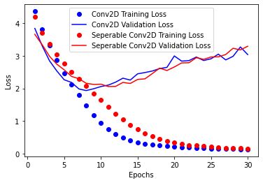

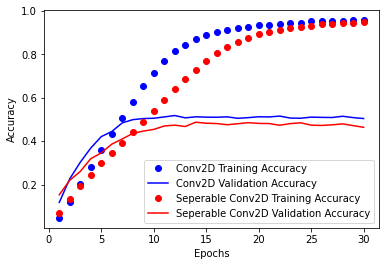

```
(None, None)
```

```python
get_max_acc_min_loss_epoch(history_15, 'Model 15: Seperable Conv2d')
compare_loss_acc(history_14, history_15, 'Conv2D', 'Seperable Conv2D')
```

The use of seperable convolution layers did not improve the model.

# 5 Pretrained model

The use of a model that has been previously trained can produce promising results. The vgg16 neural network model has been trained on much more data than this dataset and we can use that base to build off of for our dataset. By harnesing the patterns already learned in vgg16, there is a potential to be able to apply that knowledge to this dataset for an even more accurate model.

### Base Pretrained VGG16 (15, 16)

Take the pretrained model and freeze the convolutional base so that previously learned patterns in this network are kept intact during training on this dataset. First model will add two blocks of dense and dropout layers to the pretrained base which will be trained on the new dataset. Second model will unfreeze the last 3 layers of the pretrained network to fine tune the network to the new cifar100 dataset.

```python
base_model_vgg16 = keras.applications.vgg16.VGG16(
    weights='imagenet',
    input_shape = (32,32,3),
    include_top=False
)


def build_ft_model_1():

    base_model_vgg16.trainable=False

    inputs = keras.Input(shape=(32, 32, 3))

    x = keras.applications.vgg16.preprocess_input(inputs)

    x = base_model_vgg16(x, training=False)

    x = layers.Flatten()(x)

    x = layers.Dense(512, activation='relu')(x)
    x = layers.Dropout(0.5)(x)

    x = layers.Dense(512, activation='relu')(x)
    x = layers.Dropout(0.5)(x)

    outputs = layers.Dense(100, activation='softmax')(x)

    model = keras.Model(inputs=inputs, outputs=outputs, name='FT_Model')

    return model


ft_model_1 = build_ft_model_1()
```

Train model once with complete base frozen.

```python
ft_model_1.compile(
    optimizer=keras.optimizers.Adam(1e-4),
    loss = 'categorical_crossentropy',
    metrics=['accuracy'],
)

history_ft_1 = ft_model_1.fit(
    train_images,
    train_labels,
    epochs=50,
    verbose=2,
    validation_split=0.2
)
```

Unfreeze the final 3 layers and then retrain the model with a lower learning rate in order to limit any major modifacations to the pretrained network layers that have been unfrozen.

```python
base_model_vgg16.trainable = True
for layer in base_model_vgg16.layers[:-4]:
 layer.trainable = False

ft_model_1.compile(
    optimizer=keras.optimizers.Adam(1e-5),
    loss = 'categorical_crossentropy',
    metrics=['accuracy'],
)

history_ft_2 = ft_model_1.fit(
    train_images,
    train_labels,
    epochs=50,
    verbose=2,
    validation_split=0.2
)
```

```python
get_max_acc_min_loss_epoch(history_ft_1, 'Model 15: Vgg16 Base')
get_max_acc_min_loss_epoch(history_ft_2, 'Model 16: Vgg16 FT')
get_max_acc_min_loss_epoch(history_14, 'Model 14: Self Trained')
```

```
Model 15: Vgg16 Base
Max Validation Accuracy:  41.21 %	 Num Epoch:  46
Min Validation Loss:  2.34707 		 Num Epoch:  49
Model 16: Vgg16 FT
Max Validation Accuracy:  50.129999999999995 %	 Num Epoch:  48
Min Validation Loss:  2.1342 		 Num Epoch:  18
Model 14: Self Trained
Max Validation Accuracy:  51.83 %	 Num Epoch:  10
Min Validation Loss:  1.94449 		 Num Epoch:  7
```

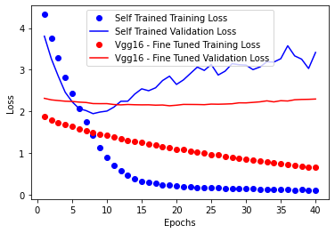

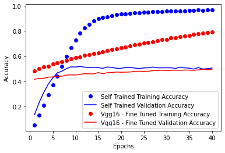

```
(None, None)
```

```python
compare_loss_acc(history_14, history_ft_2, 'Self Trained', 'Vgg16 - Fine Tuned')
```

## Table Summary of Results

```python
pd.read_csv('./cw2results2.csv').sort_values(['Min Val Loss'])
```

[output not shown]

# 6 Final Model Evaluation

The custom model 13 proved to be the best trained model with a validation accuarcy of 51.83% and a clear dip in validation loss. Fine tuning the vgg16 model was able to produce a validation accuarcy score of 50.12%. In order to test our final model, it will be retrained using all the training data, this includes the validation data previously held out. Then the model will be evaluated on the holdout test data that has not previousyl been used.

### Final Self-Trained Model (16)

```
Final Model
Max Validation Accuracy:  51.83 %	 Num Epoch:  10
Min Validation Loss:  1.94449 		 Num Epoch:  7
```

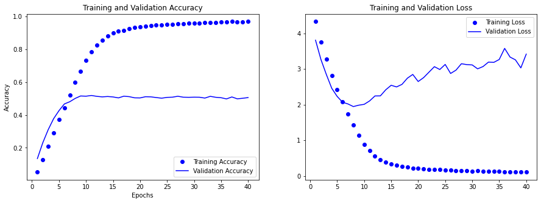

```python
get_max_acc_min_loss_epoch(history_14, 'Final Model')
plot_val_loss_acc(history_14)
```

```python
final_model_self_trained = build_model_14()
final_model_self_trained.summary()
```

```
Model: "Model_14_Residuals"
__________________________________________________________________________________________________
 Layer (type)                   Output Shape         Param #     Connected to
==================================================================================================
 input_10 (InputLayer)          [(None, 32, 32, 3)]  0           []

 rescaling_2 (Rescaling)        (None, 32, 32, 3)    0           ['input_10[0][0]']

 batch_normalization_6 (BatchNo  (None, 32, 32, 3)   12          ['rescaling_2[0][0]']
 rmalization)

 conv2d_20 (Conv2D)             (None, 32, 32, 128)  3584        ['batch_normalization_6[0][0]']

 conv2d_21 (Conv2D)             (None, 32, 32, 128)  147584      ['conv2d_20[0][0]']

 max_pooling2d_6 (MaxPooling2D)  (None, 16, 16, 128)  0          ['conv2d_21[0][0]']

 conv2d_22 (Conv2D)             (None, 16, 16, 128)  512         ['rescaling_2[0][0]']

 add_6 (Add)                    (None, 16, 16, 128)  0           ['max_pooling2d_6[0][0]',
                                                                  'conv2d_22[0][0]']

 batch_normalization_7 (BatchNo  (None, 16, 16, 128)  512        ['add_6[0][0]']
 rmalization)

 conv2d_23 (Conv2D)             (None, 16, 16, 256)  295168      ['batch_normalization_7[0][0]']

 conv2d_24 (Conv2D)             (None, 16, 16, 256)  590080      ['conv2d_23[0][0]']

 max_pooling2d_7 (MaxPooling2D)  (None, 8, 8, 256)   0           ['conv2d_24[0][0]']

 conv2d_25 (Conv2D)             (None, 8, 8, 256)    33024       ['add_6[0][0]']

 add_7 (Add)                    (None, 8, 8, 256)    0           ['max_pooling2d_7[0][0]',
                                                                  'conv2d_25[0][0]']

 batch_normalization_8 (BatchNo  (None, 8, 8, 256)   1024        ['add_7[0][0]']
 rmalization)

 conv2d_26 (Conv2D)             (None, 8, 8, 512)    1180160     ['batch_normalization_8[0][0]']
```

[output cut: 14 more lines]

```
 dense_21 (Dense)               (None, 512)          8389120     ['flatten_3[0][0]']

 dropout_18 (Dropout)           (None, 512)          0           ['dense_21[0][0]']

 dense_22 (Dense)               (None, 512)          262656      ['dropout_18[0][0]']

 dropout_19 (Dropout)           (None, 512)          0           ['dense_22[0][0]']

 dense_23 (Dense)               (None, 100)          51300       ['dropout_19[0][0]']

==================================================================================================
Total params: 18,164,720
Trainable params: 18,163,946
Non-trainable params: 774
__________________________________________________________________________________________________
```

```python
final_model_self_trained.compile(
    optimizer=keras.optimizers.Adam(1e-4),
    loss = 'categorical_crossentropy',
    metrics=['accuracy'],
)

final_model_self_trained.fit(
    train_images,
    train_labels,
    epochs=7,
    verbose=2,
)
```

```
1563/1563 - 43s - loss: 4.2799 - accuracy: 0.0570 - 43s/epoch - 28ms/step
1563/1563 - 43s - loss: 3.6256 - accuracy: 0.1484 - 43s/epoch - 27ms/step
1563/1563 - 43s - loss: 3.0400 - accuracy: 0.2494 - 43s/epoch - 27ms/step
1563/1563 - 43s - loss: 2.5584 - accuracy: 0.3438 - 43s/epoch - 27ms/step
1563/1563 - 43s - loss: 2.1579 - accuracy: 0.4293 - 43s/epoch - 28ms/step
1563/1563 - 43s - loss: 1.8168 - accuracy: 0.5033 - 43s/epoch - 28ms/step
1563/1563 - 43s - loss: 1.4914 - accuracy: 0.5799 - 43s/epoch - 28ms/step
```

```
<keras.callbacks.History at 0x7f9921bcf6a0>
```

#### Evaluate Model On Test Data

```python
final_results_self_trained = final_model_self_trained.evaluate(test_images, test_labels)
print('Final Pre-trained Model Accuracy: ', round(final_results_self_trained[1]*100,2),'%')
print('Final Pre-trained Model Loss: ', final_results_self_trained[0])
```

```
Final Pre-trained Model Accuracy:  51.79 %
Final Pre-trained Model Loss:  1.8469609022140503
```

# 7 Conclusion

# Apendix Code

#### Chart Plotting Code

```python
def plot_train_val_loss(history):
    loss = history.history['loss']
    val_loss = history.history['val_loss']

    epochs = range(1, len(loss) + 1)

    blue_dots = 'bo'
    solid_blue_line = 'b'

    plt.plot(epochs, loss, blue_dots, label = 'Training loss')
    plt.plot(epochs, val_loss, solid_blue_line, label = 'Validation loss')
    plt.title('Training and validation loss')
    plt.xlabel('Epochs')
    plt.ylabel('Loss')
    plt.legend()

    plt.show()

def plot_train_val_acc(history):
    plt.clf()

    acc = history.history['accuracy']
    val_acc = history.history['val_accuracy']

    epochs = range(1, len(acc) + 1)

    blue_dots = 'bo'
    solid_blue_line = 'b'

    plt.plot(epochs, acc, blue_dots, label = 'Training Accuracy')
    plt.plot(epochs, val_acc, solid_blue_line, label = 'Validation Accuracy')
    plt.title('Training and validation acc')
    plt.xlabel('Epochs')
    plt.ylabel('Accuracy')
    plt.legend()

def plot_val_loss_acc(history):
    acc = history.history['accuracy']
    val_acc = history.history['val_accuracy']

    loss = history.history['loss']
    val_loss = history.history['val_loss']

    epochs_range = range(1, len(acc) + 1)
    blue_dots = 'bo'
    solid_blue_line = 'b'

    plt.figure(figsize=(15, 5))

    plt.subplot(1, 2, 1)
    # plt.plot(epochs_range, acc, label='Training Accuracy')
    # plt.plot(epochs_range, val_acc, label='Validation Accuracy')


    plt.plot(epochs_range, acc, blue_dots, label = 'Training Accuracy')
    plt.plot(epochs_range, val_acc, solid_blue_line, label = 'Validation Accuracy')
    plt.legend(loc='lower right')
    plt.title('Training and Validation Accuracy')
    plt.xlabel('Epochs')
    plt.ylabel('Accuracy')
    plt.legend()

    plt.subplot(1, 2, 2)
    plt.plot(epochs_range, loss, blue_dots, label='Training Loss')
    plt.plot(epochs_range, val_loss, solid_blue_line, label='Validation Loss')
    plt.legend(loc='upper right')
    plt.title('Training and Validation Loss')
    plt.show()

def compare_loss(hist1, hist2, title1, title2):
    min_epochs = min(len(hist1.history['loss']), len(hist2.history['loss']))
    loss = hist1.history['loss'][:min_epochs]
    val_loss = hist1.history['val_loss'][:min_epochs]
    loss_drop = hist2.history['loss'][:min_epochs]
    val_loss_drop = hist2.history['val_loss'][:min_epochs]

    epochs = range(1, min_epochs + 1)

    blue_dots = 'bo'
    solid_blue_line = 'b'
    red_dots = 'ro'
    solid_red_line = 'r'

    plt.plot(epochs, loss, blue_dots, label = f'{title1} Training Loss')
    plt.plot(epochs, val_loss, solid_blue_line, label = f'{title1} Validation Loss')
    plt.plot(epochs, loss_drop, red_dots, label = f'{title2} Training Loss')
    plt.plot(epochs, val_loss_drop, solid_red_line, label = f'{title2} Validation Loss')
    # plt.title('Loss With Dropout Layers')
    plt.xlabel('Epochs')
    plt.ylabel('Loss')
    plt.legend()

    plt.show()

def compare_acc(hist1, hist2, title1, title2):
    min_epochs = min(len(hist1.history['accuracy']), len(hist2.history['accuracy']))
    acc = hist1.history['accuracy'][:min_epochs]
    val_acc = hist1.history['val_accuracy'][:min_epochs]
    acc_drop = hist2.history['accuracy'][:min_epochs]
    val_acc_drop = hist2.history['val_accuracy'][:min_epochs]

    epochs = range(1, min_epochs + 1)

    blue_dots = 'bo'
    solid_blue_line = 'b'
    red_dots = 'ro'
    solid_red_line = 'r'

    plt.plot(epochs, acc, blue_dots, label = f'{title1} Training Accuracy')
    plt.plot(epochs, val_acc, solid_blue_line, label = f'{title1} Validation Accuracy')
    plt.plot(epochs, acc_drop, red_dots, label = f'{title2} Training Accuracy')
    plt.plot(epochs, val_acc_drop, solid_red_line, label = f'{title2} Validation Accuracy')
    # plt.title('Accuracy With Dropout Layers')
    plt.xlabel('Epochs')
    plt.ylabel('Accuracy')
    plt.legend()

    plt.show()

def compare_loss_acc(hist1, hist2, title1, title2):
  return compare_loss(hist1, hist2, title1, title2), compare_acc(hist1, hist2, title1, title2)
```

#### Get Maximum Validation Accuracy and Minimum Validation Loss

Take the history from the models trained and return the maximum validation accuracy and the epoch at which it occurred as well as the minimum validation loss and the epoch at which it occurred.

```python
def get_max_val_acc_epoch(history):
  val_acc = history.history['val_accuracy']
  max_val_acc = round(max(val_acc),5)*100
  max_epoch = np.argmax(val_acc)
  print('Max Validation Accuracy: ', max_val_acc, '%\t Num Epoch: ', max_epoch)
  return

def get_min_val_loss_epoch(history):
  val_loss = history.history['val_loss']
  min_val_loss = round(min(val_loss),5)
  min_epoch = np.argmin(val_loss)
  print('Min Validation Loss: ', min_val_loss, '\t\t Num Epoch: ', min_epoch)
  return

def get_max_acc_min_loss_epoch(history, model_name):
  print(model_name)
  get_max_val_acc_epoch(history)
  get_min_val_loss_epoch(history)
```